# STAT340 Exam 2 Practice Problems

Keith Levin

Fall 2022

## Problem 1: Estimating the success parameter of a Bernoulli

The following code downloads a CSV file called `binary.csv` and reads it into a data frame `data` with one column, `X`, which is a vector of binary observations (i.e., every entry is zero or one).

```r
download.file(destfile='binary.csv', url='https://pages.stat.wisc.edu/~kdlevin/teaching/Fall2021/STAT340/Exam2/binary_data.csv')
data <- read.csv('binary.csv' )
head(data)
```

```
##   X
## 1 1
## 2 0
## 3 1
## 4 0
## 5 0
## 6 0
```

Let us suppose that these observations were drawn iid from a Bernoulli distribution with unknown success probability $p$, and we are interested in estimating $p$.

**Part a**

Use Monte Carlo to construct a 90% (**note:** 90%, not 95%) confidence interval for the parameter $p$.

```r
NMC <- 1e4;
mcreps <- rep(NA, NMC);

phat <- mean(data$X);
for( i in 1:NMC ) {
  fakedata <- rbinom(n=nrow(data), size=1, prob=phat );
  mcreps[i] <- mean(fakedata);
}

c( quantile( mcreps, 0.05), quantile( mcreps,0.95) );
```

```
##        5%       95%
## 0.2333333 0.5000000
```

**Part b**

Now, use the same method to construct a 95% confidence interval for $p$.

```r
c( quantile( mcreps, 0.025), quantile( mcreps,0.975) );
```

```
##      2.5%     97.5%
## 0.2000000 0.5333333
```

Is this CI wider or narrower than the one in Part a? Is this what you would expect? Why or why not?

The higher-confidence CI is wider. This is expected– higher confidence requires a wider range of value to encompass a larger total probability mass under the curve between our lower and upper limits.

**Part c**

Now, using the same data, construct a 95% (**note:** 95% now, like in part b, *not* 90%) CLT-based confidence interval for $p$.

```r
phat <- mean(data$X);
varhat <- var(data$X);

SEmean <- sqrt(varhat/nrow(data));
c( phat - 1.96*SEmean, phat+1.96*SEmean)
```

```
## [1] 0.1912750 0.5420583
```

**Part d**

We said in lecture that in general, these two approaches should yield fairly similar results. Is that the case here? Compare the two confidence intervals (e.g., which one is narrower, if any). A sentence or two is fine.

Yes. Indeed, the two intervals are the same within about $0.01$.

## Problem 2: Testing the effectiveness of a drug

A doctor is testing a new drug for treating disease X. The doctor assigns a group of 60 patients with disease X randomly to two different groups: treatment and control. The treatment group is given the experiment drug. The control group is given a placebo. A month later, the doctor records whether or not each person in the study still has disease X, and records the result as a 1 if the patient is still sick, and a 0 otherwise.

The following code downloads the data from this (obviously fictional) experiment and stores it in a data frame `diseaseX`. Each row of this data frame corresponds to a patient in the study. The data frame has two columns: `Group` encodes whether each patient was assigned to the treatment (`T`) or control (`C`) group. `Disease` captures whether or not a patient had disease X at the end of the experiment (`1` for sick, `0` for cured).

```r
download.file(destfile='diseaseX.csv', url='https://pages.stat.wisc.edu/~kdlevin/teaching/Fall2021/STAT340/Exam2/diseaseX_data.csv')
diseaseX <- read.csv('diseaseX.csv' )
head(diseaseX)
```

```
##   Group Disease
## 1     C       1
## 2     C       0
## 3     C       1
## 4     C       1
## 5     C       1
## 6     C       1
```

**Part a**

Using everything you know, test the hypothesis that the doctor’s experimental treatment has no effect on disease status at the 95% level under the assumption that the data are modeled as independent Bernoulli-distributed observations.

```r
head(diseaseX)
```

```
##   Group Disease
## 1     C       1
## 2     C       0
## 3     C       1
## 4     C       1
## 5     C       1
## 6     C       1
```

```r
nC <- sum( diseaseX$Group=='C')
nT <- sum( diseaseX$Group=='T')
ntotal <- nC + nT;

NMC <- 1e4;
mcreps <- rep(NA, NMC);
for( i in 1:NMC ) {
  shuf <- sample( diseaseX$Disease )
  ctlmean <- mean(shuf[1:nC]);
  trtmean <- mean(shuf[(nC+1):ntotal]);
  mcreps[i] <- ctlmean - trtmean;
}

c( quantile(mcreps, 0.025), quantile(mcreps, 0.975) )
```

```
##  2.5% 97.5%
##  -0.2   0.2
```

```r
diff_obsd <- mean(diseaseX[diseaseX$Group=='C',]$Disease) -mean(diseaseX[diseaseX$Group=='T',]$Disease);

diff_obsd
```

```
## [1] 0.2666667
```

Our observed test statistic is outside the $95\%$ CI, indicating that we should reject the null that the treatment has no effect at the level $\alpha=0.05$.

**Part b**

Suppose that we model the patients in the control group as being diseased with probability $p_C$ and, similarly, a treatment patient is diseased with probability $p_T$. That is, we model the `Disease` entries in the data frame `diseaseX` above as being independent Bernoullis with success probability $p_C$ for the control patients and $p_T$ for the treatment patients.

Let’s define the *strength* $\delta$ of the treatment to be the difference between these two different probabilities:
$$\delta = p_T - p_C.$$
Using everything you know, construct a 95% confidence interval for $\delta$.

**Hint:** we recommend using simulation-based inference (of course, a CLT-based CI is also possible, if you prefer): what would you do if you had access to a machine that generated more data for you? Estimate $p_T$ and $p_C$, pretend they are the truth, and do whatever it is you would do if you had that machine.

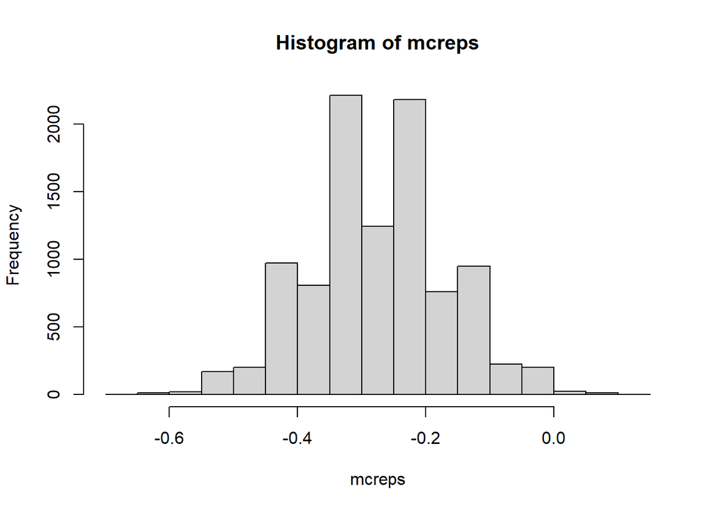

```r
phatC <- mean(diseaseX[diseaseX$Group=='C',]$Disease);
phatT <- mean(diseaseX[diseaseX$Group=='T',]$Disease);

simulate_once <- function() {
  fakectl <- rbinom(n=nC, size=1, prob=phatC);
  faketrt <- rbinom(n=nT, size=1, prob=phatT);
  return( mean(faketrt) - mean(fakectl) );
}

NMC <- 1e4;
mcreps <- rep(NA, NMC);
for( i in 1:NMC ) {
  mcreps[i] <- simulate_once()
}

hist(mcreps)
```

```r
c( quantile(mcreps, 0.025), quantile(mcreps, 0.975) )
```

```
##        2.5%       97.5%
## -0.46666667 -0.06666667
```

**Note:** the sign of $\delta$ is opposite that of the quantity we were working with in the earlier parts of this solution. This is to illustrate that so long as you are consistent within the code designed to answer a particular statistical question, your conclusions will not be appreciably changed (other than switching signs, of course).

## Problem 3: Constructing a confidence interval

Load the `cats` data, which includes sex (`Sex`, coded as `M` or `F`), body weight (`Bwt`, in kilograms) and heart weight (`Hwt`, in grams).

```r
library(MASS)
head(cats)
```

```
##   Sex Bwt Hwt
## 1   F 2.0 7.0
## 2   F 2.0 7.4
## 3   F 2.0 9.5
## 4   F 2.1 7.2
## 5   F 2.1 7.3
## 6   F 2.1 7.6
```

Consider the ratio $R$ formed by dividing cat cat’s heart weight by the body weight, and let $\rho$ denote the population mean of this quantity.

### Part a) Constructing a CLT-based CI

Using the `cats` data set, construct a CLT-based $95\%$ confidence interval for the mean heart weight to body weight ratio $\rho$.

```r
R <- cats$Hwt/cats$Bwt;

varhat <- var(R);
muhat <- mean(R);
ncat <- nrow(cats)

c(muhat - 1.96*sqrt(varhat/ncat), muhat + 1.96*sqrt(varhat/ncat) )
```

```
## [1] 3.815357 3.987166
```

What is the lower limit of this CI? The upper limit?

### Part b) Constructing a simulation-based CI

Under the assumption that $R$ is normally distributed about its mean $\rho$ with an unknown variance $\sigma^2$, use the `cats` data set to construct a simulation-based $95\%$ confidence interval for the mean heart weight to body weight ratio $\rho$. Your simulation should use at least 10,000 Monte Carlo iterates.

**Hint:** use the data to estimate $\sigma^2$, then proceed with the simulation-based CLT “recipe” that we used in lecture and discussion section.

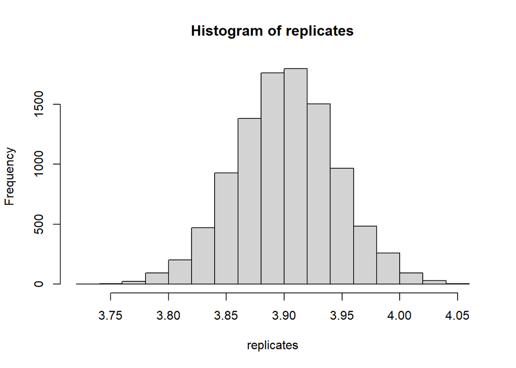

```r
sigma2hat <- var( R )
muhat <- mean(R)

NMC <- 1e4
replicates <- rep(NA, NMC);

for(i in 1:NMC) {
  fakedata <- rnorm(n=ncat, mean=muhat, sd=sqrt(sigma2hat));
  replicates[i] <- mean(fakedata)
}

hist(replicates)
```

```r
c( quantile(replicates, 0.025), quantile(replicates,0.975)  )
```

```
##     2.5%    97.5%
## 3.814588 3.988193
```

## Problem 4: Conditional Probability

In the `mtcars` data set, there are two columns corresponding to the engine shape (`vs`; coded as $0$ for V-shape cylinder configuation, $1$ for “straight” cylinder configuration) and the transmission type (`am`; coded as $0$ for automatic and $1$ for manual).

Assuming that the rows of the `mtcars` data set are an independent sample from a population (a questionable assumption, but let’s suspend our disbelief for now), estimate the following probabilities:

1. The probability that a random car is a manual with a V-shaped engine.

```r
sum(mtcars$am==1 & mtcars$vs==0)/nrow(mtcars)
```

```
## [1] 0.1875
```

2. The probability that a random car has a V-shaped engine *given* that it is a manual transmission

```r
sum(mtcars$am==1 & mtcars$vs==0)/sum(mtcars$am==1)
```

```
## [1] 0.4615385
```

3. The probability that a random car has a manual transmission *given* that it has a V-shaped engine.

```r
sum(mtcars$am==1 & mtcars$vs==0)/sum(mtcars$vs==0)
```

```
## [1] 0.3333333
```